# Homework#3 - Possible variables that has a strong correlation with partnership status

Riyesh Nath

2025-09-17

**GROUP MEMBERS:** Bamba Cisse, Nasrin and Marwan Kenawy

### Summary:

In this project, we will do a data exploration of household pulse data and try to find variables that can allows us to find a strong correlation with a person’s partnership status.

- The variables that we will test are:
  - Education’s effect on partnership status.
  - Race and Gender’s effect on partnership status
  - Effects of Age on Partnership Status
  - How Employment Type Affects Marital Status

```r
library(ggplot2)
library(tibble)
library(dplyr)
library(gridExtra)
load("data/d_HHP2020_24.Rdata")
attach(d_HHP2020_24)
```

#### Bamba Cisse – Education’s effect on partnership status

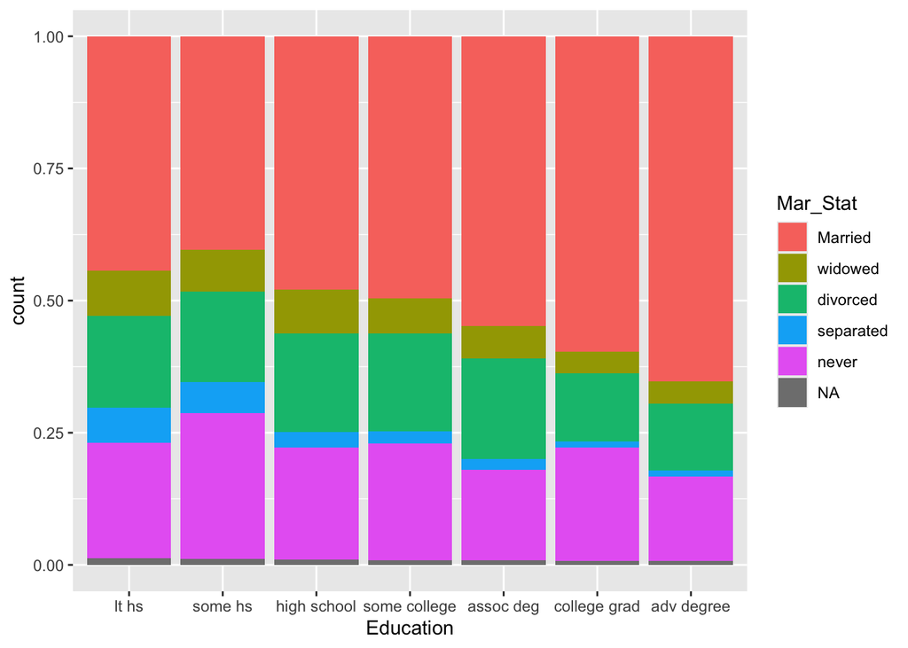

```r
p <- ggplot(data = d_HHP2020_24,
            mapping = aes(x = Education, fill = Mar_Stat))
p + geom_bar(position = "fill")
```

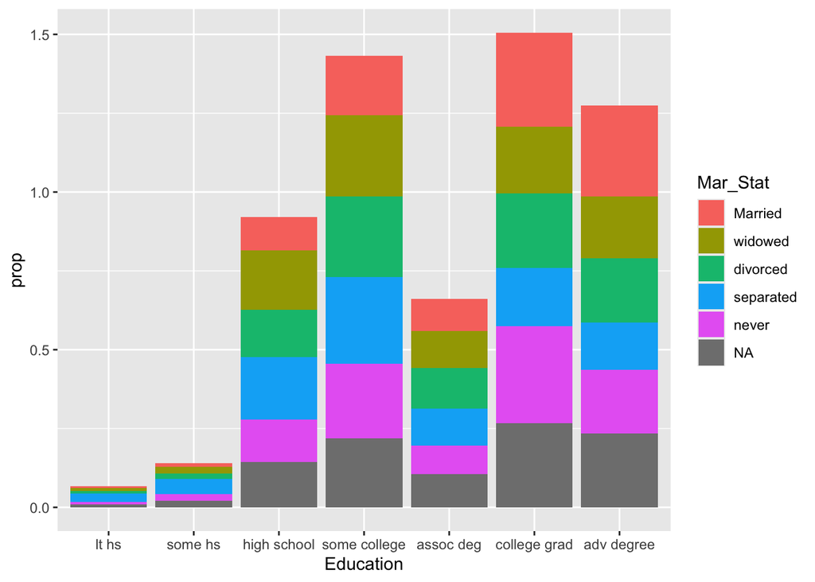

```r
p + geom_bar(mapping = aes(
  y = after_stat(prop),
  group = Mar_Stat))
```

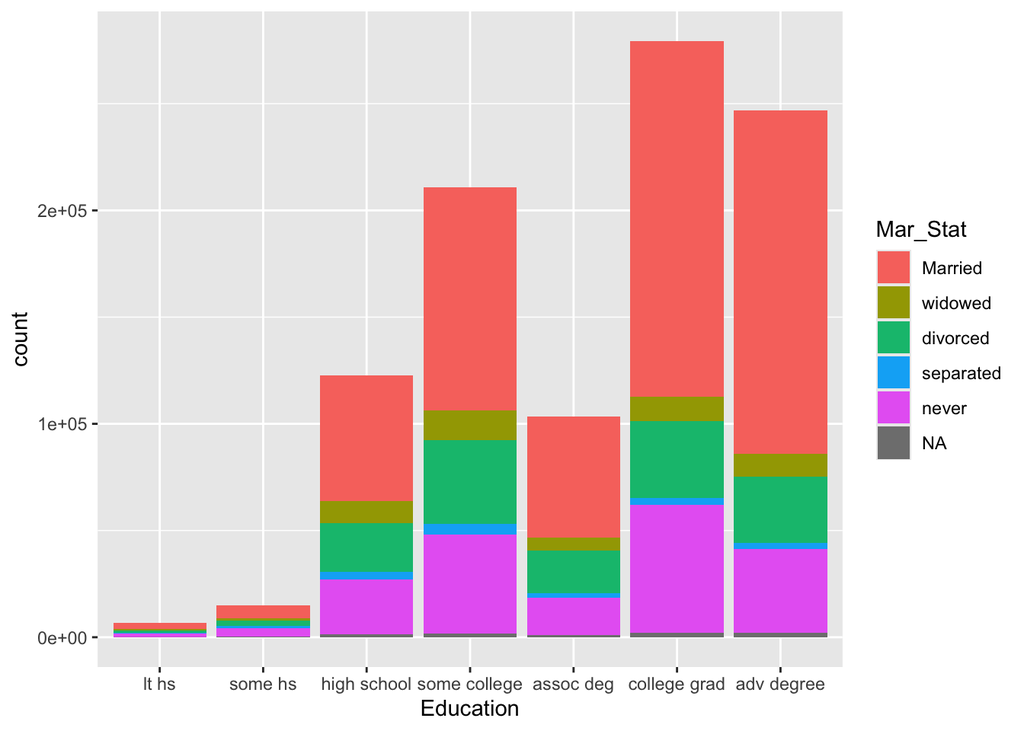

```r
p <- ggplot(data = d_HHP2020_24,
            mapping = aes(x = Education, fill = Mar_Stat))
p + geom_bar()
```

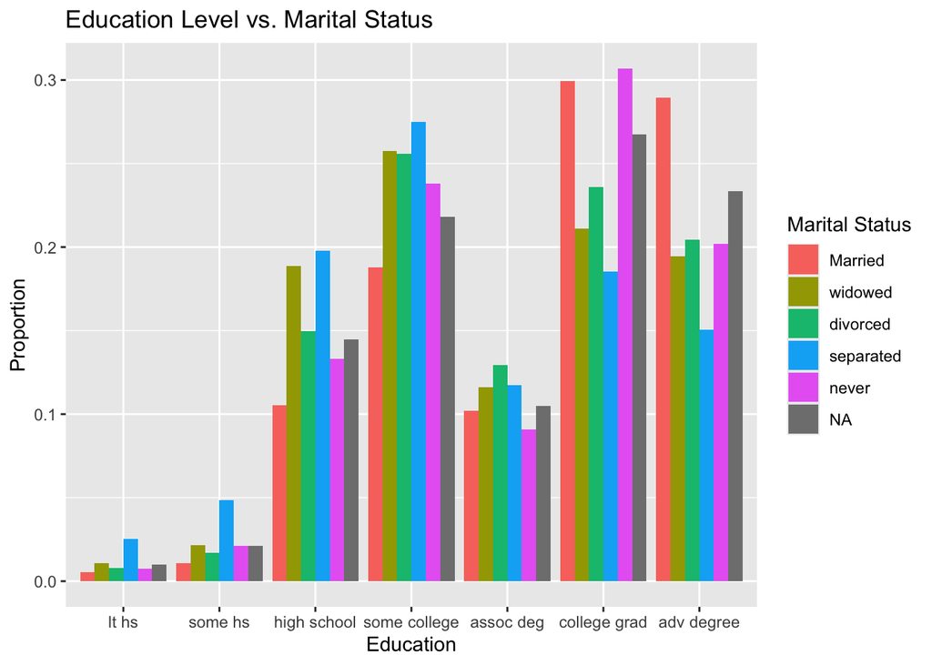

```r
p + geom_bar( position = "dodge",
    mapping = aes(y = after_stat(prop), group = Mar_Stat, fill = Mar_Stat)
  ) +
  labs(title = "Education Level vs. Marital Status",
    x = "Education",y = "Proportion",fill = "Marital Status")
```